# PfSPZ correlation chord diagrams (gene level) using postvax non transcriptomic and baseline gene expression

Prasida Holla

1/20/2022

## Objective:

To make linear correlations between the PfSPZ vaccine baseline transcriptomic data and post-vaccination non-transcriptomic data, the latter of which includes select features from the phenoData, and flow cytometric parameters. The transcriptomic data from RNA-seq is presented as such, and not collapsed into BTMs or other modules.This analysis was done based on reviewers’ comments to validate transcription modules that came up as strongly correlated with non-transcriptomic features at a gene level. The correlations are visualized as a chord diagram or circos plot.

Steps: 1. Filter and keep select features from non-transcriptomic data (Phil Swanson’s FACS data qnd post-vaccination CSP-specific IgG antibody levels- remove cytokine levels) 2. Load the baseline expression set and filter the phenoData for post-vaccination time point (25 for post-vaccination), and time to parasitemia at 6 months. 3. Merge the selected phenoData features with the filtered non-transcriptomic data. We will call this “alldata” 4. Analyse baseline gene expression data: Filter out low expressing genes and select genes with fraction of highest variation. Add a ‘handle’ or label to each gene ("_gene“) so that gene to gene correlations can be filtered out from the final correlation matrix. 5. Run correlations using ggcorrplot- either by merging the”alldata" with the filtered gene expression data using patient ID or loop across the two dataframes. 6. The correlation analysis should give a table of Pearson’s r values and pvalues for each correlation pair 7. Convert pvalues to FDR and use it to keep only significant correlations 8. Keeping only the top triangle of the correlation matrix and remove gene to gene correlations. 9. Use the package ‘circlize’ to visualize the correlations as a chord diagram (aka circos plot). 10. This script is specifically for baseline gene expression to post-vaccination FACS features.

## Load required packages

```r
library(tidyverse)
library(tibble)
library(viridis)
library(ggpubr)
library(readxl)
library(ggcorrplot)
library(org.Hs.eg.db)
library(Biobase)
library(miscTools)
library(circlize)
library(RColorBrewer)
library(doBy)
library(googledrive)
library(stats)
library(data.table)
library(Cairo)
library(EDASeq)
```

# Import baseline and post-vax expression sets, and facs data

```r
#load the baseline expression dataset
temp <- tempfile(fileext = ".rds")
dl <- drive_download(
  as_id("1Q4VXYxdl9CqtzhcvHA9pn8q06_YOZgi8"), path = temp, overwrite = TRUE)
esetb <- readRDS(file = dl$local_path)

#load the post-vaccination expression dataset
temp <- tempfile(fileext = ".rds")
dl <- drive_download(
  as_id("10loQKUl7pQs0qxpDQv1VkCULIL9ZbawZ"), path = temp, overwrite = TRUE)
esetp <- readRDS(file = dl$local_path)

##import all non-transcriptomic data
temp <- tempfile(fileext = ".rds")
dl <- drive_download(
  as_id("10Uv9gzqZTVtyIqEmYdE9JpJUnJ8ZCPdT"), path = temp, overwrite = TRUE)
facs <- readRDS(file = dl$local_path)
```

#Keep only select columns from the phenoData of the post-vaccination EpressionSet (Patient ID,Sample ID, time to parasitemia at six months)

```r
positions<-c(1, 2, 3, 8, 12)
pData(esetp)<-  pData(esetp)%>%
dplyr::select(positions)
```

#Keep only select columns from the post-vaccination non-transcriptomic data

```r
facs<-facs %>%
  dplyr::select(!contains("log2 fold-change anti-CSP IgG")) %>%
  dplyr::select(!contains("FACS_CD3+_of_live_lymphocytes")) %>%
  dplyr::select(!contains("FACS_PfSPZ-specific_CD3+_of_live_lymphocytes")) %>%
  dplyr::select(!contains("FACS_CD3+_of_live_PBMCs")) %>%
  dplyr::select(!contains("FACS_PfSPZ-specific_CD3+_of_live_PBMCs")) %>%
  dplyr::select(!contains("FACS_CD3+CD4+_of_live_lymphocytes")) %>%
  #dplyr::select(!contains("FACS_PfSPZ-specific_CD3+CD4+_of_live_lymphocytes")) %>%
  dplyr::select(!contains("FACS_CD3+CD4+_of_live_PBMCs")) %>%
  dplyr::select(!contains("FACS_PfSPZ-specific_CD3+CD4+_of_live_PBMCs")) %>%
  dplyr::select(!contains("FACS_CD3+CD8+_of_live_lymphocytes")) %>%
  #dplyr::select(!contains("FACS_PfSPZ-specific_CD3+CD8+_of_live_lymphocytes")) %>%
  dplyr::select(!contains("FACS_CD3+CD8+_of_live_PBMCs")) %>%
  dplyr::select(!contains("FACS_PfSPZ-specific_CD3+CD8+_of_live_PBMCs")) %>%
  #dplyr::select(!contains("FACS_CD19+_of_live_lymphocytes")) %>%
  dplyr::select(!contains("FACS_CD19+_of_live_PBMCs")) %>%
  #dplyr::select(!contains("FACS_Plasmablasts_of_live_lymphocytes")) %>%
  dplyr::select(!contains("FACS_Plasmablasts_of_live_PBMCs")) %>%
  dplyr::select(!contains("FACS_CSP-specific_memory_B_cells_of_live_lymphocytes")) %>%
  dplyr::select(!contains("FACS_CSP-specific_memory_B_cells_of_live_leukocytes")) %>%
  # dplyr::select(!contains("FACS_CD11c+_of_live_monocytes")) %>%
  dplyr::select(!contains("FACS_CD11c+_of_live_PBMCs")) %>%
  #dplyr::select(!contains("FACS_CD14+_of_live_monocytes")) %>%
  dplyr::select(!contains("FACS_CD14+_of_live_PBMCs")) %>%
  dplyr::select(!contains("FACS_CD56+CD16+_of_live_lymphocytes")) %>%
  dplyr::select(!contains("FACS_CD56+CD16+_of_live_PBMCs")) %>%
  dplyr::select(!contains("FACS_memory_of_B_cells")) %>%
  dplyr::select(!contains("FACS_naive_of_B_cells")) %>%
  dplyr::select(!contains("FACS_IgG+_of_memory")) %>%
  dplyr::select(!contains("FACS_IgM+_of_memory")) %>%
  dplyr::select(!contains("FACS_IgG-IgM-_of_memory")) %>%
  #dplyr::select(!contains("FACS_CSP-spec_of_memory_B_cells")) %>%
  dplyr::select(!contains("FACS_CSP-spec_of_B_cells")) %>%
  #dplyr::select(!contains("FACS_IgG_of_CSP-spec")) %>%
  #dplyr::select(!contains("FACS_IgM_of_CSP-spec")) %>%
  #dplyr::select(!contains("FACS_IgG-IgM-_of_CSP-spec")) %>%
  dplyr::select(!contains("FACS_PBs_of_memory")) %>%
  dplyr::select(!contains("FACS_PBs_of_B_cells")) %>%
  #dplyr::select(!contains("FACS_atypical_memory_of_B_cells")) %>%
  dplyr::select(!contains("FACS_immature_of_B_cells")) %>%
  dplyr::select(!contains("FACS_TCRgd")) %>%
  dplyr::select(!contains("FACS_PfSPZ-specific_TCRgd")) %>%
  dplyr::select(!contains("FACS_Vd1_of_T_cells")) %>%
  #dplyr::select(!contains("FACS_PfSPZ-specific_Vd1_of_T_cells")) %>%
  dplyr::select(!contains("FACS_Vd1_of_TCRgd")) %>%
  dplyr::select(!contains("FACS_PfSPZ-specific_Vd1_of_TCRgd")) %>%
  dplyr::select(!contains("FACS_Vd1/2-_of_T_cells")) %>%
  #dplyr::select(!contains("FACS_PfSPZ-specific_Vd1/2-_of_T_cells")) %>%
  dplyr::select(!contains("FACS_Vd1/2-_of_TCRgd")) %>%
  dplyr::select(!contains("FACS_PfSPZ-specific_Vd1/2-_of_TCRgd")) %>%
  dplyr::select(!contains("FACS_Vd2_of_T_cells")) %>%
  dplyr::select(!contains("FACS_PfSPZ-specific_Vd2_of_T_cells")) %>%
  dplyr::select(!contains("FACS_Vd2_of_TCRgd")) %>%
  dplyr::select(!contains("FACS_PfSPZ-specific_Vd2_of_TCRgd")) %>%
  dplyr::select(!contains("FACS_Vg9-_of_Vd2_cells")) %>%
  dplyr::select(!contains("FACS_PfSPZ-specific_Vg9-_of_Vd2_cells")) %>%
  dplyr::select(!contains("FACS_Vg9-Vd2+_of_T_cells")) %>%
  #dplyr::select(!contains("FACS_PfSPZ-specific_Vg9-Vd2+_of_T_cells")) %>%
  dplyr::select(!contains("FACS_Vg9-Vd2+_of_TCRgd")) %>%
  dplyr::select(!contains("FACS_PfSPZ-specific_Vg9-Vd2+_of_TCRgd")) %>%
  dplyr::select(!contains("FACS_Vg9+_of_Vd2_cells")) %>%
  dplyr::select(!contains("FACS_PfSPZ-specific_Vg9+_of_Vd2_cells")) %>%
  dplyr::select(!contains("FACS_Vg9+Vd2+_of_T_cells")) %>%
  #dplyr::select(!contains("FACS_PfSPZ-specific_Vg9+Vd2+_of_T_cells")) %>%
  dplyr::select(!contains("FACS_Vg9+Vd2+_of_TCRgd")) %>%
  dplyr::select(!contains("FACS_PfSPZ-specific_Vg9+Vd2+_of_TCRgd")) %>%
  #dplyr::select(!contains("FACS_CD14+CD16+_of_live_monocytes")) %>%
  dplyr::select(!contains("FACS_CD14+CD16+_of_live_PBMCs")) %>%
  #dplyr::select(!contains("FACS_CD14+CD16-_of_live_monocytes")) %>%
  dplyr::select(!contains("FACS_CD14+CD16-_of_live_PBMCs")) %>%
  #dplyr::select(!contains("FACS_CD14-CD16+_of_live_monocytes")) %>%
  dplyr::select(!contains("FACS_CD14-CD16+_of_live_PBMCs"))%>%
  dplyr::select(!contains("CytokineObsConc_CCL2_MCP-1")) %>%
  dplyr::select(!contains("CytokineObsConc_CCL4_MIP-1_beta")) %>%
  dplyr::select(!contains("CytokineObsConc_CXCL10_IP-10")) %>%
  dplyr::select(!contains("CytokineObsConc_GM-CSF")) %>%
  dplyr::select(!contains("CytokineObsConc_IFN-alpha")) %>%
  dplyr::select(!contains("CytokineObsConc_IFN-beta")) %>%
  dplyr::select(!contains("CytokineObsConc_IFN-gamma")) %>%
  dplyr::select(!contains("CytokineObsConc_IL-1_beta")) %>%
  dplyr::select(!contains("CytokineObsConc_IL-10")) %>%
  dplyr::select(!contains("CytokineObsConc_IL-12_p70")) %>%
  dplyr::select(!contains("CytokineObsConc_IL-2")) %>%
dplyr::select(!contains("CytokineObsConc_IL-4")) %>%
dplyr::select(!contains("CytokineObsConc_IL-6")) %>%
dplyr::select(!contains("CytokineObsConc_IL-8_CXCL8")) %>%
dplyr::select(!contains("CytokineObsConc_TNF-alpha")) %>%
dplyr::select(!contains("ICS_IL-1ß_pct_of_live_monocytes")) %>%
  dplyr::select(!contains("ICS_IL-1ß_Count")) %>%
  dplyr::select(!contains("ICS_IL-1ß_MFI_live_monocytes")) %>%
  dplyr::select(!contains("ICS_IL-8_pct_of_live_monocytes")) %>%
  dplyr::select(!contains("ICS_IL-8_Count")) %>%
  dplyr::select(!contains("ICS_IL-8_MFI_live_monocytes")) %>%
  dplyr::select(!contains("ICS_TNF_pct_of_live_monocytes")) %>%
  dplyr::select(!contains("ICS_CD86_MFI_live_monocytes")) %>%
  dplyr::select(!contains("ICS_HLA-DR_MFI_live_monocytes"))%>%
  dplyr::select(!contains("ICS_TNF_MFI_live_monocytes")) %>%
  dplyr::select(!contains("ICS_TNF_count"))

#Keep only post-vaccination values
facs<-facs%>% filter(grepl("_25", PATID.OG))
```

#Merge non-transcriptomic data ‘facs’ with the pData of post-vaccination ‘esetp’

```r
pheno_data<-pData(esetp)%>%rownames_to_column(., var="PATID.OG")
#Merge
alldata<-pheno_data%>%left_join(., facs, by="PATID.OG")

# Remove unwanted columns
alldata<-alldata[, -c(2:5,7)]
```

# Process gene expression data at baseline

```r
# Step 1: Filter gene expression.
# Remove low level expressors
e<-counts(esetb)
# Write a 'selectgenes' function to keep rows (transcripts, genes) that have at least min.count reads in a minimum proportion of samples given by N. By default evaluates to ‘TRUE’ if >=90% (N=0.9 ) of the samples have count-per-million (CPM) above _k_, where _k_ is determined by the default value of min.count=10 and by the sample library. More info on this: https://seqqc.wordpress.com/2020/02/17/removing-low-count-genes-for-rna-seq-downstream-analysis/

selectGenes <- function(counts, min.count=10, N=0.90){
  lib.size <- colSums(counts)
  MedianLibSize <- median(lib.size)
  CPM.Cutoff <- min.count / MedianLibSize*1e6
  CPM <- edgeR::cpm(counts,lib.size=lib.size)

  min.samples <- round(N * ncol(counts))

  f1 <- genefilter::kOverA(min.samples, CPM.Cutoff)
  flist <- genefilter::filterfun(f1)
  keep <- genefilter::genefilter(CPM, flist)

  return(keep)
}

# and filter your eset
keep.exprs <- selectGenes(e, min.count=10, N=0.90)
myFilt <- e[keep.exprs,]
#dim(myFilt)

# Remove time point T=25
myFilt<-myFilt[,c(1:244)]

# now keep only highest variance genes:

# Option 1: Filter gene expression based on median absolute deviation filtering:

madsno <- as.integer(nrow(myFilt)/2) # There are ~14.5K genes after filtering out low expressors, we will select the top 50%, alternately select top 1000 genes
mads <- apply(myFilt, 1, mad)
e <-myFilt[mads > sort(mads, decr=TRUE)[madsno],]

# Option 2: Filter gene expression based on genefilter. Mostly recommended for microarray data and thresholding is based on absolute intensity cutoffs. However, it works on any matri and cutoffs based on  counts/ cpms for RNA-seq can also be implemented. More info here: https://bioconductor.org/packages/release/bioc/html/genefilter.html and https://support.bioconductor.org/p/72002/

#my_fun <- genefilter::filterfun(pOverA(p = 0.4, A = 100), cv(a = 0.7, b = 10))
#my_filter <- genefilter(2^myFilt, my_fun)
#e- myFilt[my_filter,]


# Scale data
e<- e %>%
t(.) %>%
scale(., center = TRUE, scale = TRUE) %>%
t(.)

# ENSEMBLIDs to gene names
symbols <- mapIds(org.Hs.eg.db,
keys=row.names(e),
column="SYMBOL",
keytype="ENSEMBL",
multiVals="first")
expr_data<-merge(e, symbols, by=0)
expr_data<-expr_data[,-1]
ncol(expr_data)
```

```
## [1] 245
```

```r
expr_data<-expr_data[!duplicated(expr_data$y),]
expr_data<-expr_data[!is.na(expr_data$y),] ## or you can run --> expr_data<-subset(expr_data, !is.na(expr_data$y))
rownames(expr_data)<-(expr_data[,245])
expr_data<-expr_data[,-245]

# Clean up and transpose
gene_data<-data.frame(expr_data)%>%rownames_to_column(., var = "Genes")
gene_data<-t(gene_data)
colnames(gene_data) <- gene_data[1,]
gene_data<-gene_data[-1,]
gene_data<-data.frame(gene_data)%>%rownames_to_column(., var="PATID.OG")

#Change all the scores in the expr_data from 'factor' to 'numeric'
# Note: This changes the PATID.OG column to numeric as well and fills it in with NAs. Merge the PATID.OGs from expr_data (above) to the new dataframe by assigning the numeric dataframe a new name, 'gene_data'
indx <- sapply(gene_data, is.character)
gene_data[indx] <- lapply(gene_data[indx], function(x) as.numeric(as.character(x)))
gene_data<-gene_data[, -1]
e<-t(expr_data)
e<-as.data.frame(e)%>%rownames_to_column(., var="PATID.OG")
gene_data$`PATID.OG`<-e[,1]
gene_data <- gene_data %>%
  dplyr::select("PATID.OG", everything())
```

# Add “Gene_” to each of the gene names (to filter out gene to gene correlatiosn later)

```r
colnames(gene_data)<-paste(colnames(gene_data), "_Gene")
gene_data<-gene_data%>%dplyr::rename(., "PATID.OG"="PATID.OG _Gene")
```

# For convenience, change patient_ids in the non-transcriptomic ‘alldata’ from time ’_25’ to time ’_0’

```r
alldata<-alldata%>%dplyr::mutate(., "PATID.OG"=str_replace(PATID.OG, '_.*', "_0"))
```

# Keep the same Patient_ids in baseline gene expression data and post-vaccination non-transcriptomic data

```r
gene_data<-gene_data%>% filter(., PATID.OG %in% alldata$PATID.OG)
nrow(gene_data)
```

```
## [1] 230
```

```r
alldata<-alldata%>% filter(., PATID.OG %in% gene_data$PATID.OG)
nrow(alldata)
```

```
## [1] 230
```

# Option I: Loop across the two sepearte dataframes

```r
#Spe 1: Trim to remove PATID.OGs
#gene_data<-gene_data[,-1]
#alldata<-alldata[,-1]

# For help : https://stackoverflow.com/questions/67692320/nested-loop-in-r-to-correlate-columns-of-df1-to-columns-of-df2

# Step 2: Get rho values
#r <- matrix(NA, nrow = ncol(gene_data), ncol=ncol(alldata))
#for (i in 1:ncol(gene_data)) {
#for (j in 1:ncol(alldata)) {
#r[i, j] <- cor.test(gene_data[,i], alldata[,j], method = "spearman")$estimate
#}
#}

# Get pvalues
#p <- matrix(NA, nrow = ncol(gene_data), ncol=ncol(alldata))
#for (i in 1:ncol(gene_data)) {
#for (j in 1:ncol(alldata)) {
#p[i, j] <- cor.test(gene_data[,i], alldata[,j], method = "spearman")$p.value
#}
#}

# Re-assign names to rows and columns
#rownames(r)<-colnames(gene_data)
#colnames(r)<-colnames(alldata)

#rownames(p)<-colnames(gene_data)
#colnames(p)<-colnames(alldata)
```

## Option II: Correlating within the same merged matrix

```r
# Merge the gene_data with alldata
big<-alldata%>%
left_join(., gene_data,  by="PATID.OG")
big<-big[,-1]

# Rename columns for convenience
big<-big %>%
  dplyr::rename("Outcome" = "tte.mal.atp.6") %>%
  dplyr::rename("PfSPZ stimulated CD4+ T cells" = "FACS_PfSPZ-specific_CD3+CD4+_of_live_lymphocytes")%>%
  dplyr::rename( "PfSPZ stimulated CD8+ T cells"= "FACS_PfSPZ-specific_CD3+CD8+_of_live_lymphocytes")%>%
  dplyr::rename("CD19+ B cells" = "FACS_CD19+_of_live_lymphocytes")%>%
  dplyr::rename("FACS Plasmablasts" = "FACS_Plasmablasts_of_live_lymphocytes")%>%
  dplyr::rename("CD11c+ monocytes" = "FACS_CD11c+_of_live_monocytes")%>%
  dplyr::rename("CD14+ monocytes" = "FACS_CD14+_of_live_monocytes")%>%
  dplyr::rename("CSP specific of memory B cells" = "FACS_CSP-spec_of_memory_B_cells")%>%
  dplyr::rename("IgG+ of CSP specific B cells" = "FACS_IgG_of_CSP-spec")%>%
  dplyr::rename("IgM+ of CSP specific B cells" = "FACS_IgM_of_CSP-spec")%>%
  dplyr::rename("IgG-IgM- of CSP specific B cells"= "FACS_IgG-IgM-_of_CSP-spec")%>%
  dplyr::rename("Atypical memory of B cells" = "FACS_atypical_memory_of_B_cells")%>%
  dplyr::rename("PfSPZ stimulated Vδ1 of T cells"  = "FACS_PfSPZ-specific_Vd1_of_T_cells")%>%
  dplyr::rename("PfSPZ stimulated Vδ1/2 of T cells"  = "FACS_PfSPZ-specific_Vd1/2-_of_T_cells")%>%
  dplyr::rename("PfSPZ stimulated Vδ9-Vδ2+ of T cells"  = "FACS_PfSPZ-specific_Vg9-Vd2+_of_T_cells")%>%
  dplyr::rename("PfSPZ stimulated Vδ9+Vδ2+ of T cells"  = "FACS_PfSPZ-specific_Vg9+Vd2+_of_T_cells")%>%
  dplyr::rename("CD14+CD16+ of monocytes"  = "FACS_CD14+CD16+_of_live_monocytes")%>%
  dplyr::rename("CD14+CD16- of monocytes"  = "FACS_CD14+CD16-_of_live_monocytes")%>%
  dplyr::rename("CD14-CD16+ of monocytes"  = "FACS_CD14-CD16+_of_live_monocytes")%>%
  dplyr::rename("Postvax anti-CSP IgG"  = "anti-CSP IgG")
```

# Run the correlations and make cutoffs

```r
cor_btm<-cor(na.omit(big), use = "pairwise.complete.obs")
# Create a p value matrix
p.mat_btm<-cor_pmat(na.omit(big), use="pairwise.complete.obs")
# Convert p values to False Discovery Rates
p.mat_btm[]<-p.adjust(p.mat_btm, method = 'BH' )
p.mat_btm[lower.tri(p.mat_btm, diag=TRUE)] <- NA   #use adjusted P values
p.mat_btm <- pmax(p.mat_btm, t(p.mat_btm), na.rm=TRUE)
fdr <- 0.001
d_sig_btm  <- which(p.mat_btm <fdr, arr.ind = T)
foo_cor_btm <- cor_btm[unique(d_sig_btm[,1]),unique(d_sig_btm[,2])]  #get row and columns that include significant values
foo_pval_btm <- p.mat_btm[unique(d_sig_btm[,1]),unique(d_sig_btm[,2])]  #get row and columns that include significant values
foo_cor_btm[foo_pval_btm>=fdr] <- 0                                 #for cor values not signficant, make 0
foo_cor_btm[foo_cor_btm>0.999999] <- 0                                 #for cor values that are
```

# Remove gene to gene correlations and remove negative correlations

```r
indx_col <- grepl('Gene', colnames(foo_cor_btm))
indx_row <- grepl('Gene', rownames(foo_cor_btm))
foo_cor_btm[indx_row, indx_col]<-0
foo_cor_btm[foo_cor_btm<0] <- 0
foo_cor_btm[foo_cor_btm == 0] <- NA
```

# Create sectors for the chord diagram: Note: this part runs into errors and sectors are not created

# Error message: “chr` contains index that does not beling to available sectors”

```r
combo3_btm<-as.data.frame(foo_cor_btm)
combo3_btm$Data.Type <- "Gene Expression"
combo3_btm$Data.Type <- ifelse(grepl("Outcome", rownames(combo3_btm)), "Outcome", combo3_btm$Data.Type)
combo3_btm$Data.Type <- ifelse(grepl("PfSPZ stimulated CD4\\+ T cells", rownames(combo3_btm)), "Cellular expression", combo3_btm$Data.Type)
combo3_btm$Data.Type <- ifelse(grepl("PfSPZ stimulated CD8\\+ T cells", rownames(combo3_btm)), "Cellular expression", combo3_btm$Data.Type)
combo3_btm$Data.Type <- ifelse(grepl("CD19\\+ B cells", rownames(combo3_btm)), "Cellular expression", combo3_btm$Data.Type)
combo3_btm$Data.Type <- ifelse(grepl("FACS Plasmablasts", rownames(combo3_btm)), "Cellular expression", combo3_btm$Data.Type)
combo3_btm$Data.Type <- ifelse(grepl("CD11c\\+ monocytes", rownames(combo3_btm)), "Cellular expression", combo3_btm$Data.Type)
combo3_btm$Data.Type <- ifelse(grepl("CD14\\+ monocytes", rownames(combo3_btm)), "Cellular expression", combo3_btm$Data.Type)
combo3_btm$Data.Type <- ifelse(grepl("CSP specific of memory B cells", rownames(combo3_btm)), "Cellular expression", combo3_btm$Data.Type)
combo3_btm$Data.Type <- ifelse(grepl("IgM\\+ of CSP specific B cells", rownames(combo3_btm)), "Cellular expression", combo3_btm$Data.Type)
combo3_btm$Data.Type <- ifelse(grepl("IgG\\+ of CSP specific B cells", rownames(combo3_btm)), "Cellular expression", combo3_btm$Data.Type)
combo3_btm$Data.Type <- ifelse(grepl("IgG\\-IgM\\- of CSP specific B cells", rownames(combo3_btm)), "Cellular expression", combo3_btm$Data.Type)
combo3_btm$Data.Type <- ifelse(grepl("Atypical memory of B cells", rownames(combo3_btm)), "Cellular expression", combo3_btm$Data.Type)
combo3_btm$Data.Type <- ifelse(grepl("PfSPZ stimulated Vδ1 of T cells", rownames(combo3_btm)), "Cellular expression", combo3_btm$Data.Type)
combo3_btm$Data.Type <- ifelse(grepl("PfSPZ stimulated Vδ1/2 of T cells", rownames(combo3_btm)), "Cellular expression", combo3_btm$Data.Type)
combo3_btm$Data.Type <- ifelse(grepl("PfSPZ stimulated Vδ9\\-Vδ2\\+ of T cells", rownames(combo3_btm)), "Cellular expression", combo3_btm$Data.Type)
combo3_btm$Data.Type <- ifelse(grepl("PfSPZ stimulated Vδ9\\+Vδ2\\+ of T cells", rownames(combo3_btm)), "Cellular expression", combo3_btm$Data.Type)
combo3_btm$Data.Type <- ifelse(grepl("CD14\\+CD16\\+ of monocytes", rownames(combo3_btm)), "Cellular expression", combo3_btm$Data.Type)
combo3_btm$Data.Type <- ifelse(grepl("CD14\\+CD16\\- of monocytes", rownames(combo3_btm)), "Cellular expression", combo3_btm$Data.Type)
combo3_btm$Data.Type <- ifelse(grepl("CD14\\-CD16\\+ of monocytes", rownames(combo3_btm)), "Cellular expression", combo3_btm$Data.Type)
combo3_btm$Data.Type <- ifelse(grepl("Postvax anti-CSP IgG", rownames(combo3_btm)), "Outcome", combo3_btm$Data.Type)


set.seed(12)
df1_btm <- data.frame(variable = as.character(rownames(combo3_btm)), Group1 = combo3_btm$Data.Type)
gl1_btm <- split(df1_btm$variable, df1_btm$Group1, drop = FALSE)
gl1_btm <- sapply(gl1_btm, as.character)
group_color1_btm <- structure(circlize::rand_color(length(gl1_btm),hue = "monochrome", transparency = 0.5, luminosity = "dark"), names = names(gl1_btm))
n_group1_btm <-  length(gl1_btm)

## to get CSP-specific IgG, outcome and dose together
combo3_btm<-combo3_btm %>% arrange(factor(Data.Type, levels = c("Outcome","Cellular expression", "Gene Expression")))

combo4_btm <- combo3_btm[,intersect(rownames(combo3_btm), colnames(combo3_btm))]


combo4_btm[upper.tri(combo4_btm)] <- 0
combo4_btm[combo4_btm<0] <- 0
combo4_btm[combo4_btm == 0] <- NA
```

# Note; Highlight sectors and relabeling of gene names was done in AI

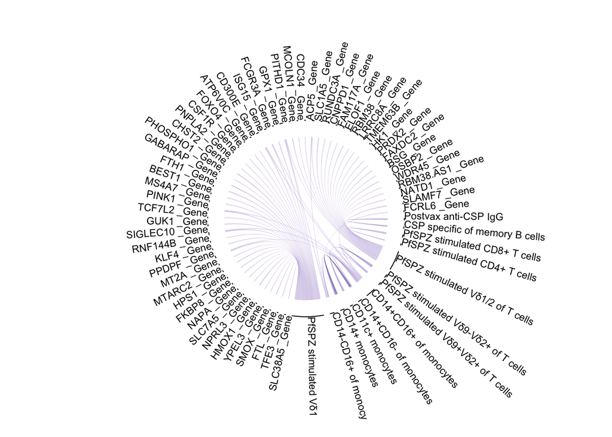

```r
mat_btm <- as.matrix(combo4_btm)
order_btm<-colnames(mat_btm)
col_fun_btm <- colorRamp2(c( 0, 1), c( "white", "darkblue"), transparency = 0.5)

#cairo_pdf("~/Desktop/Baseline_GE_to_post_vax_chord.pdf", height = 6, width = 6)
circos.par(canvas.xlim = c(-1.8,1.8), canvas.ylim = c(-1.8,1.8), points.overflow.warning=FALSE,
track.margin = c(0.01, 0.05), # adjust bottom and top margin
track.height = 0.05,  gap.degree =4)
chordDiagram(mat_btm, order=order_btm, col = col_fun_btm(mat_btm), annotationTrack = NULL, link.largest.ontop = TRUE, preAllocateTracks = list(track.height = 0.1), transparency = 0.25, self.link = 1)
circos.trackPlotRegion(track.index = 1, panel.fun = function(x, y) {
xlim = get.cell.meta.data("xlim")
ylim = get.cell.meta.data("ylim")
sector.name = get.cell.meta.data("sector.index")
circos.text(mean(xlim), ylim[1] + 1, sector.name, facing = "clockwise", niceFacing = TRUE, adj = c(0, 0), cex = 0.7) #text for parameters
circos.axis(h = "top", labels.cex = 0.3, major.tick = FALSE, sector.index = sector.name, track.index = 1, labels = FALSE)
}, bg.border = NA)
```

```r
#highlight.sector(rownames(mat_btm)[which(combo3_btm$Data.Type == "Gene Expression")],
#                 track.index = get.all.track.index(), col = "cyan",
#                 text = "Gene Expression", cex = 0.8, text.col = "black", niceFacing = T)
#highlight.sector(rownames(combo3_btm)[which(combo3_btm$Data.Type == "Outcome")],
#                 track.index = get.all.track.index(), col = "grey",
#                 text = "Outcome", cex = 0.8, text.col = "black", niceFacing = TRUE)
# Cellular Expression
#highlight.sector(rownames(combo3_btm)[which(combo3_btm$Data.Type == "Cellular expression")],
#                 track.index = get.all.track.index(), col = "green",
#                 text = "Cellular Expression", cex = 0.8, text.col = "pink", niceFacing = TRUE)
circos.clear()
```

# Testing individual comparisons

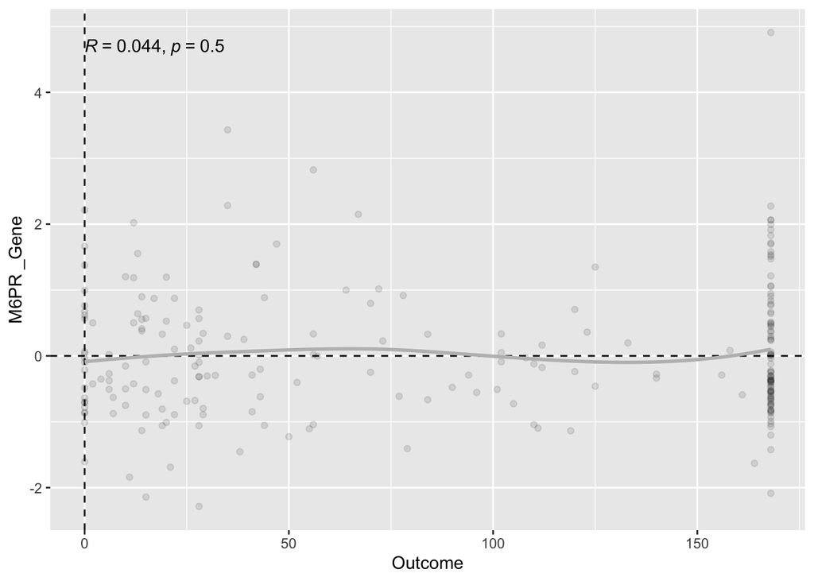

```r
# Keep only the comparisons that were not NA
x<-which(!is.na(mat_btm), arr.ind = T)
for_scatters<-mat_btm[unique(x[,1]), unique(x[,2])]

# Create a fuction to plot all pairs of scatterplots at once
rows<-set_names(rownames(for_scatters))
cols<-set_names(colnames(for_scatters))

scatter_fun = function(x, y) {
   ggplot(big, aes(x = .data[[x]], y = .data[[y]]) )+
        geom_point(alpha=0.1)+
        theme()+
          geom_hline(yintercept = 0, linetype="dashed")+
          geom_vline(xintercept = 0, linetype="dashed")+
        stat_cor(mapping = NULL, data = NULL, method = "pearson", label.sep = ", ", label.x.npc = "left", label.y.npc = "top", label.x = NULL, label.y = NULL, output.type = "expression", geom = "text", position = "identity", na.rm = FALSE, show.legend = NA, inherit.aes = TRUE)+
    geom_smooth(method = "loess", se = FALSE, color = "grey74")
}

# Example
scatter_fun("Outcome", "M6PR _Gene")
```

```r
# Plot all together
all_plots <-map(rows, ~map(cols, scatter_fun, y = .x) )

cairo_pdf("~/Desktop/scatterPlots.pdf")
all_plots
```

```
## $`CSP specific of memory B cells`
## $`CSP specific of memory B cells`$`Postvax anti-CSP IgG`
```

```
##
## $`CSP specific of memory B cells`$`PfSPZ stimulated CD8+ T cells`
```

```
##
## $`CSP specific of memory B cells`$`PfSPZ stimulated Vδ1/2 of T cells`
```

```
##
## $`CSP specific of memory B cells`$`PfSPZ stimulated Vδ9-Vδ2+ of T cells`
```

```
##
## $`CSP specific of memory B cells`$`PfSPZ stimulated Vδ9+Vδ2+ of T cells`
```

```
##
## $`CSP specific of memory B cells`$`CD14+CD16+ of monocytes`
```

```
##
## $`CSP specific of memory B cells`$`CD14+CD16- of monocytes`
```

```
##
## $`CSP specific of memory B cells`$`CD14-CD16+ of monocytes`
```

```
##
## $`CSP specific of memory B cells`$`PfSPZ stimulated Vδ1 of T cells`
```

```
##
##
## $`PfSPZ stimulated CD4+ T cells`
## $`PfSPZ stimulated CD4+ T cells`$`Postvax anti-CSP IgG`
```

```
##
## $`PfSPZ stimulated CD4+ T cells`$`PfSPZ stimulated CD8+ T cells`
```

```
##
## $`PfSPZ stimulated CD4+ T cells`$`PfSPZ stimulated Vδ1/2 of T cells`
```

```
##
## $`PfSPZ stimulated CD4+ T cells`$`PfSPZ stimulated Vδ9-Vδ2+ of T cells`
```

```
##
## $`PfSPZ stimulated CD4+ T cells`$`PfSPZ stimulated Vδ9+Vδ2+ of T cells`
```

```
##
## $`PfSPZ stimulated CD4+ T cells`$`CD14+CD16+ of monocytes`
```

```
##
## $`PfSPZ stimulated CD4+ T cells`$`CD14+CD16- of monocytes`
```

```
##
## $`PfSPZ stimulated CD4+ T cells`$`CD14-CD16+ of monocytes`
```

```
##
## $`PfSPZ stimulated CD4+ T cells`$`PfSPZ stimulated Vδ1 of T cells`
```

```
##
##
## $`PfSPZ stimulated Vδ1/2 of T cells`
## $`PfSPZ stimulated Vδ1/2 of T cells`$`Postvax anti-CSP IgG`
```

```
##
## $`PfSPZ stimulated Vδ1/2 of T cells`$`PfSPZ stimulated CD8+ T cells`
```

```
##
## $`PfSPZ stimulated Vδ1/2 of T cells`$`PfSPZ stimulated Vδ1/2 of T cells`
```

```
##
## $`PfSPZ stimulated Vδ1/2 of T cells`$`PfSPZ stimulated Vδ9-Vδ2+ of T cells`
```

```
##
## $`PfSPZ stimulated Vδ1/2 of T cells`$`PfSPZ stimulated Vδ9+Vδ2+ of T cells`
```

```
##
## $`PfSPZ stimulated Vδ1/2 of T cells`$`CD14+CD16+ of monocytes`
```

```
##
## $`PfSPZ stimulated Vδ1/2 of T cells`$`CD14+CD16- of monocytes`
```

```
##
## $`PfSPZ stimulated Vδ1/2 of T cells`$`CD14-CD16+ of monocytes`
```

```
##
## $`PfSPZ stimulated Vδ1/2 of T cells`$`PfSPZ stimulated Vδ1 of T cells`
```

```
##
##
## $`GPX1 _Gene`
## $`GPX1 _Gene`$`Postvax anti-CSP IgG`
```

```
##
## $`GPX1 _Gene`$`PfSPZ stimulated CD8+ T cells`
```

```
##
## $`GPX1 _Gene`$`PfSPZ stimulated Vδ1/2 of T cells`
```

```
##
## $`GPX1 _Gene`$`PfSPZ stimulated Vδ9-Vδ2+ of T cells`
```

```
##
## $`GPX1 _Gene`$`PfSPZ stimulated Vδ9+Vδ2+ of T cells`
```

```
##
## $`GPX1 _Gene`$`CD14+CD16+ of monocytes`
```

```
##
## $`GPX1 _Gene`$`CD14+CD16- of monocytes`
```

```
##
## $`GPX1 _Gene`$`CD14-CD16+ of monocytes`
```

```
##
## $`GPX1 _Gene`$`PfSPZ stimulated Vδ1 of T cells`
```

```
##
##
## $`PITHD1 _Gene`
## $`PITHD1 _Gene`$`Postvax anti-CSP IgG`
```

```
##
## $`PITHD1 _Gene`$`PfSPZ stimulated CD8+ T cells`
```

```
##
## $`PITHD1 _Gene`$`PfSPZ stimulated Vδ1/2 of T cells`
```

```
##
## $`PITHD1 _Gene`$`PfSPZ stimulated Vδ9-Vδ2+ of T cells`
```

```
##
## $`PITHD1 _Gene`$`PfSPZ stimulated Vδ9+Vδ2+ of T cells`
```

```
##
## $`PITHD1 _Gene`$`CD14+CD16+ of monocytes`
```

```
##
## $`PITHD1 _Gene`$`CD14+CD16- of monocytes`
```

```
##
## $`PITHD1 _Gene`$`CD14-CD16+ of monocytes`
```

```
##
## $`PITHD1 _Gene`$`PfSPZ stimulated Vδ1 of T cells`
```

```
##
##
## $`MCOLN1 _Gene`
## $`MCOLN1 _Gene`$`Postvax anti-CSP IgG`
```

```
##
## $`MCOLN1 _Gene`$`PfSPZ stimulated CD8+ T cells`
```

```
##
## $`MCOLN1 _Gene`$`PfSPZ stimulated Vδ1/2 of T cells`
```

```
##
## $`MCOLN1 _Gene`$`PfSPZ stimulated Vδ9-Vδ2+ of T cells`
```

```
##
## $`MCOLN1 _Gene`$`PfSPZ stimulated Vδ9+Vδ2+ of T cells`
```

```
##
## $`MCOLN1 _Gene`$`CD14+CD16+ of monocytes`
```

```
##
## $`MCOLN1 _Gene`$`CD14+CD16- of monocytes`
```

```
##
## $`MCOLN1 _Gene`$`CD14-CD16+ of monocytes`
```

```
##
## $`MCOLN1 _Gene`$`PfSPZ stimulated Vδ1 of T cells`
```

```
##
##
## $`CDC34 _Gene`
## $`CDC34 _Gene`$`Postvax anti-CSP IgG`
```

```
##
## $`CDC34 _Gene`$`PfSPZ stimulated CD8+ T cells`
```

```
##
## $`CDC34 _Gene`$`PfSPZ stimulated Vδ1/2 of T cells`
```

```
##
## $`CDC34 _Gene`$`PfSPZ stimulated Vδ9-Vδ2+ of T cells`
```

```
##
## $`CDC34 _Gene`$`PfSPZ stimulated Vδ9+Vδ2+ of T cells`
```

```
##
## $`CDC34 _Gene`$`CD14+CD16+ of monocytes`
```

```
##
## $`CDC34 _Gene`$`CD14+CD16- of monocytes`
```

```
##
## $`CDC34 _Gene`$`CD14-CD16+ of monocytes`
```

```
##
## $`CDC34 _Gene`$`PfSPZ stimulated Vδ1 of T cells`
```

```
##
##
## $`ACP5 _Gene`
## $`ACP5 _Gene`$`Postvax anti-CSP IgG`
```

```
##
## $`ACP5 _Gene`$`PfSPZ stimulated CD8+ T cells`
```

```
##
## $`ACP5 _Gene`$`PfSPZ stimulated Vδ1/2 of T cells`
```

```
##
## $`ACP5 _Gene`$`PfSPZ stimulated Vδ9-Vδ2+ of T cells`
```

```
##
## $`ACP5 _Gene`$`PfSPZ stimulated Vδ9+Vδ2+ of T cells`
```

```
##
## $`ACP5 _Gene`$`CD14+CD16+ of monocytes`
```

```
##
## $`ACP5 _Gene`$`CD14+CD16- of monocytes`
```

```
##
## $`ACP5 _Gene`$`CD14-CD16+ of monocytes`
```

```
##
## $`ACP5 _Gene`$`PfSPZ stimulated Vδ1 of T cells`
```

```
##
##
## $`SLC1A5 _Gene`
## $`SLC1A5 _Gene`$`Postvax anti-CSP IgG`
```

```
##
## $`SLC1A5 _Gene`$`PfSPZ stimulated CD8+ T cells`
```

```
##
## $`SLC1A5 _Gene`$`PfSPZ stimulated Vδ1/2 of T cells`
```

```
##
## $`SLC1A5 _Gene`$`PfSPZ stimulated Vδ9-Vδ2+ of T cells`
```

```
##
## $`SLC1A5 _Gene`$`PfSPZ stimulated Vδ9+Vδ2+ of T cells`
```

```
##
## $`SLC1A5 _Gene`$`CD14+CD16+ of monocytes`
```

```
##
## $`SLC1A5 _Gene`$`CD14+CD16- of monocytes`
```

```
##
## $`SLC1A5 _Gene`$`CD14-CD16+ of monocytes`
```

```
##
## $`SLC1A5 _Gene`$`PfSPZ stimulated Vδ1 of T cells`
```

```
##
##
## $`RUNDC3A _Gene`
## $`RUNDC3A _Gene`$`Postvax anti-CSP IgG`
```

```
##
## $`RUNDC3A _Gene`$`PfSPZ stimulated CD8+ T cells`
```

```
##
## $`RUNDC3A _Gene`$`PfSPZ stimulated Vδ1/2 of T cells`
```

```
##
## $`RUNDC3A _Gene`$`PfSPZ stimulated Vδ9-Vδ2+ of T cells`
```

```
##
## $`RUNDC3A _Gene`$`PfSPZ stimulated Vδ9+Vδ2+ of T cells`
```

```
##
## $`RUNDC3A _Gene`$`CD14+CD16+ of monocytes`
```

```
##
## $`RUNDC3A _Gene`$`CD14+CD16- of monocytes`
```

```
##
## $`RUNDC3A _Gene`$`CD14-CD16+ of monocytes`
```

```
##
## $`RUNDC3A _Gene`$`PfSPZ stimulated Vδ1 of T cells`
```

```
##
##
## $`CNPPD1 _Gene`
## $`CNPPD1 _Gene`$`Postvax anti-CSP IgG`
```

```
##
## $`CNPPD1 _Gene`$`PfSPZ stimulated CD8+ T cells`
```

```
##
## $`CNPPD1 _Gene`$`PfSPZ stimulated Vδ1/2 of T cells`
```

```
##
## $`CNPPD1 _Gene`$`PfSPZ stimulated Vδ9-Vδ2+ of T cells`
```

```
##
## $`CNPPD1 _Gene`$`PfSPZ stimulated Vδ9+Vδ2+ of T cells`
```

```
##
## $`CNPPD1 _Gene`$`CD14+CD16+ of monocytes`
```

```
##
## $`CNPPD1 _Gene`$`CD14+CD16- of monocytes`
```

```
##
## $`CNPPD1 _Gene`$`CD14-CD16+ of monocytes`
```

```
##
## $`CNPPD1 _Gene`$`PfSPZ stimulated Vδ1 of T cells`
```

```
##
##
## $`FAM117A _Gene`
## $`FAM117A _Gene`$`Postvax anti-CSP IgG`
```

```
##
## $`FAM117A _Gene`$`PfSPZ stimulated CD8+ T cells`
```

```
##
## $`FAM117A _Gene`$`PfSPZ stimulated Vδ1/2 of T cells`
```

```
##
## $`FAM117A _Gene`$`PfSPZ stimulated Vδ9-Vδ2+ of T cells`
```

```
##
## $`FAM117A _Gene`$`PfSPZ stimulated Vδ9+Vδ2+ of T cells`
```

```
##
## $`FAM117A _Gene`$`CD14+CD16+ of monocytes`
```

```
##
## $`FAM117A _Gene`$`CD14+CD16- of monocytes`
```

```
##
## $`FAM117A _Gene`$`CD14-CD16+ of monocytes`
```

```
##
## $`FAM117A _Gene`$`PfSPZ stimulated Vδ1 of T cells`
```

```
##
##
## $`ELOF1 _Gene`
## $`ELOF1 _Gene`$`Postvax anti-CSP IgG`
```

```
##
## $`ELOF1 _Gene`$`PfSPZ stimulated CD8+ T cells`
```

```
##
## $`ELOF1 _Gene`$`PfSPZ stimulated Vδ1/2 of T cells`
```

```
##
## $`ELOF1 _Gene`$`PfSPZ stimulated Vδ9-Vδ2+ of T cells`
```

```
##
## $`ELOF1 _Gene`$`PfSPZ stimulated Vδ9+Vδ2+ of T cells`
```

```
##
## $`ELOF1 _Gene`$`CD14+CD16+ of monocytes`
```

```
##
## $`ELOF1 _Gene`$`CD14+CD16- of monocytes`
```

```
##
## $`ELOF1 _Gene`$`CD14-CD16+ of monocytes`
```

```
##
## $`ELOF1 _Gene`$`PfSPZ stimulated Vδ1 of T cells`
```

```
##
##
## $`RBM38 _Gene`
## $`RBM38 _Gene`$`Postvax anti-CSP IgG`
```

```
##
## $`RBM38 _Gene`$`PfSPZ stimulated CD8+ T cells`
```

```
##
## $`RBM38 _Gene`$`PfSPZ stimulated Vδ1/2 of T cells`
```

```
##
## $`RBM38 _Gene`$`PfSPZ stimulated Vδ9-Vδ2+ of T cells`
```

```
##
## $`RBM38 _Gene`$`PfSPZ stimulated Vδ9+Vδ2+ of T cells`
```

```
##
## $`RBM38 _Gene`$`CD14+CD16+ of monocytes`
```

```
##
## $`RBM38 _Gene`$`CD14+CD16- of monocytes`
```

```
##
## $`RBM38 _Gene`$`CD14-CD16+ of monocytes`
```

```
##
## $`RBM38 _Gene`$`PfSPZ stimulated Vδ1 of T cells`
```

```
##
##
## $`LRRC8A _Gene`
## $`LRRC8A _Gene`$`Postvax anti-CSP IgG`
```

```
##
## $`LRRC8A _Gene`$`PfSPZ stimulated CD8+ T cells`
```

```
##
## $`LRRC8A _Gene`$`PfSPZ stimulated Vδ1/2 of T cells`
```

```
##
## $`LRRC8A _Gene`$`PfSPZ stimulated Vδ9-Vδ2+ of T cells`
```

```
##
## $`LRRC8A _Gene`$`PfSPZ stimulated Vδ9+Vδ2+ of T cells`
```

```
##
## $`LRRC8A _Gene`$`CD14+CD16+ of monocytes`
```

```
##
## $`LRRC8A _Gene`$`CD14+CD16- of monocytes`
```

```
##
## $`LRRC8A _Gene`$`CD14-CD16+ of monocytes`
```

```
##
## $`LRRC8A _Gene`$`PfSPZ stimulated Vδ1 of T cells`
```

```
##
##
## $`TMEM63B _Gene`
## $`TMEM63B _Gene`$`Postvax anti-CSP IgG`
```

```
##
## $`TMEM63B _Gene`$`PfSPZ stimulated CD8+ T cells`
```

```
##
## $`TMEM63B _Gene`$`PfSPZ stimulated Vδ1/2 of T cells`
```

```
##
## $`TMEM63B _Gene`$`PfSPZ stimulated Vδ9-Vδ2+ of T cells`
```

```
##
## $`TMEM63B _Gene`$`PfSPZ stimulated Vδ9+Vδ2+ of T cells`
```

```
##
## $`TMEM63B _Gene`$`CD14+CD16+ of monocytes`
```

```
##
## $`TMEM63B _Gene`$`CD14+CD16- of monocytes`
```

```
##
## $`TMEM63B _Gene`$`CD14-CD16+ of monocytes`
```

```
##
## $`TMEM63B _Gene`$`PfSPZ stimulated Vδ1 of T cells`
```

```
##
##
## $`HK1 _Gene`
## $`HK1 _Gene`$`Postvax anti-CSP IgG`
```

```
##
## $`HK1 _Gene`$`PfSPZ stimulated CD8+ T cells`
```

```
##
## $`HK1 _Gene`$`PfSPZ stimulated Vδ1/2 of T cells`
```

```
##
## $`HK1 _Gene`$`PfSPZ stimulated Vδ9-Vδ2+ of T cells`
```

```
##
## $`HK1 _Gene`$`PfSPZ stimulated Vδ9+Vδ2+ of T cells`
```

```
##
## $`HK1 _Gene`$`CD14+CD16+ of monocytes`
```

```
##
## $`HK1 _Gene`$`CD14+CD16- of monocytes`
```

```
##
## $`HK1 _Gene`$`CD14-CD16+ of monocytes`
```

```
##
## $`HK1 _Gene`$`PfSPZ stimulated Vδ1 of T cells`
```

```
##
##
## $`PRDX2 _Gene`
## $`PRDX2 _Gene`$`Postvax anti-CSP IgG`
```

```
##
## $`PRDX2 _Gene`$`PfSPZ stimulated CD8+ T cells`
```

```
##
## $`PRDX2 _Gene`$`PfSPZ stimulated Vδ1/2 of T cells`
```

```
##
## $`PRDX2 _Gene`$`PfSPZ stimulated Vδ9-Vδ2+ of T cells`
```

```
##
## $`PRDX2 _Gene`$`PfSPZ stimulated Vδ9+Vδ2+ of T cells`
```

```
##
## $`PRDX2 _Gene`$`CD14+CD16+ of monocytes`
```

```
##
## $`PRDX2 _Gene`$`CD14+CD16- of monocytes`
```

```
##
## $`PRDX2 _Gene`$`CD14-CD16+ of monocytes`
```

```
##
## $`PRDX2 _Gene`$`PfSPZ stimulated Vδ1 of T cells`
```

```
##
##
## $`FAXDC2 _Gene`
## $`FAXDC2 _Gene`$`Postvax anti-CSP IgG`
```

```
##
## $`FAXDC2 _Gene`$`PfSPZ stimulated CD8+ T cells`
```

```
##
## $`FAXDC2 _Gene`$`PfSPZ stimulated Vδ1/2 of T cells`
```

```
##
## $`FAXDC2 _Gene`$`PfSPZ stimulated Vδ9-Vδ2+ of T cells`
```

```
##
## $`FAXDC2 _Gene`$`PfSPZ stimulated Vδ9+Vδ2+ of T cells`
```

```
##
## $`FAXDC2 _Gene`$`CD14+CD16+ of monocytes`
```

```
##
## $`FAXDC2 _Gene`$`CD14+CD16- of monocytes`
```

```
##
## $`FAXDC2 _Gene`$`CD14-CD16+ of monocytes`
```

```
##
## $`FAXDC2 _Gene`$`PfSPZ stimulated Vδ1 of T cells`
```

```
##
##
## $`BSG _Gene`
## $`BSG _Gene`$`Postvax anti-CSP IgG`
```

```
##
## $`BSG _Gene`$`PfSPZ stimulated CD8+ T cells`
```

```
##
## $`BSG _Gene`$`PfSPZ stimulated Vδ1/2 of T cells`
```

```
##
## $`BSG _Gene`$`PfSPZ stimulated Vδ9-Vδ2+ of T cells`
```

```
##
## $`BSG _Gene`$`PfSPZ stimulated Vδ9+Vδ2+ of T cells`
```

```
##
## $`BSG _Gene`$`CD14+CD16+ of monocytes`
```

```
##
## $`BSG _Gene`$`CD14+CD16- of monocytes`
```

```
##
## $`BSG _Gene`$`CD14-CD16+ of monocytes`
```

```
##
## $`BSG _Gene`$`PfSPZ stimulated Vδ1 of T cells`
```

```
##
##
## $`OSBP2 _Gene`
## $`OSBP2 _Gene`$`Postvax anti-CSP IgG`
```

```
##
## $`OSBP2 _Gene`$`PfSPZ stimulated CD8+ T cells`
```

```
##
## $`OSBP2 _Gene`$`PfSPZ stimulated Vδ1/2 of T cells`
```

```
##
## $`OSBP2 _Gene`$`PfSPZ stimulated Vδ9-Vδ2+ of T cells`
```

```
##
## $`OSBP2 _Gene`$`PfSPZ stimulated Vδ9+Vδ2+ of T cells`
```

```
##
## $`OSBP2 _Gene`$`CD14+CD16+ of monocytes`
```

```
##
## $`OSBP2 _Gene`$`CD14+CD16- of monocytes`
```

```
##
## $`OSBP2 _Gene`$`CD14-CD16+ of monocytes`
```

```
##
## $`OSBP2 _Gene`$`PfSPZ stimulated Vδ1 of T cells`
```

```
##
##
## $`WDR45 _Gene`
## $`WDR45 _Gene`$`Postvax anti-CSP IgG`
```

```
##
## $`WDR45 _Gene`$`PfSPZ stimulated CD8+ T cells`
```

```
##
## $`WDR45 _Gene`$`PfSPZ stimulated Vδ1/2 of T cells`
```

```
##
## $`WDR45 _Gene`$`PfSPZ stimulated Vδ9-Vδ2+ of T cells`
```

```
##
## $`WDR45 _Gene`$`PfSPZ stimulated Vδ9+Vδ2+ of T cells`
```

```
##
## $`WDR45 _Gene`$`CD14+CD16+ of monocytes`
```

```
##
## $`WDR45 _Gene`$`CD14+CD16- of monocytes`
```

```
##
## $`WDR45 _Gene`$`CD14-CD16+ of monocytes`
```

```
##
## $`WDR45 _Gene`$`PfSPZ stimulated Vδ1 of T cells`
```

```
##
##
## $`RBM38.AS1 _Gene`
## $`RBM38.AS1 _Gene`$`Postvax anti-CSP IgG`
```

```
##
## $`RBM38.AS1 _Gene`$`PfSPZ stimulated CD8+ T cells`
```

```
##
## $`RBM38.AS1 _Gene`$`PfSPZ stimulated Vδ1/2 of T cells`
```

```
##
## $`RBM38.AS1 _Gene`$`PfSPZ stimulated Vδ9-Vδ2+ of T cells`
```

```
##
## $`RBM38.AS1 _Gene`$`PfSPZ stimulated Vδ9+Vδ2+ of T cells`
```

```
##
## $`RBM38.AS1 _Gene`$`CD14+CD16+ of monocytes`
```

```
##
## $`RBM38.AS1 _Gene`$`CD14+CD16- of monocytes`
```

```
##
## $`RBM38.AS1 _Gene`$`CD14-CD16+ of monocytes`
```

```
##
## $`RBM38.AS1 _Gene`$`PfSPZ stimulated Vδ1 of T cells`
```

```
##
##
## $`NATD1 _Gene`
## $`NATD1 _Gene`$`Postvax anti-CSP IgG`
```

```
##
## $`NATD1 _Gene`$`PfSPZ stimulated CD8+ T cells`
```

```
##
## $`NATD1 _Gene`$`PfSPZ stimulated Vδ1/2 of T cells`
```

```
##
## $`NATD1 _Gene`$`PfSPZ stimulated Vδ9-Vδ2+ of T cells`
```

```
##
## $`NATD1 _Gene`$`PfSPZ stimulated Vδ9+Vδ2+ of T cells`
```

```
##
## $`NATD1 _Gene`$`CD14+CD16+ of monocytes`
```

```
##
## $`NATD1 _Gene`$`CD14+CD16- of monocytes`
```

```
##
## $`NATD1 _Gene`$`CD14-CD16+ of monocytes`
```

```
##
## $`NATD1 _Gene`$`PfSPZ stimulated Vδ1 of T cells`
```

```
##
##
## $`PfSPZ stimulated Vδ9+Vδ2+ of T cells`
## $`PfSPZ stimulated Vδ9+Vδ2+ of T cells`$`Postvax anti-CSP IgG`
```

```
##
## $`PfSPZ stimulated Vδ9+Vδ2+ of T cells`$`PfSPZ stimulated CD8+ T cells`
```

```
##
## $`PfSPZ stimulated Vδ9+Vδ2+ of T cells`$`PfSPZ stimulated Vδ1/2 of T cells`
```

```
##
## $`PfSPZ stimulated Vδ9+Vδ2+ of T cells`$`PfSPZ stimulated Vδ9-Vδ2+ of T cells`
```

```
##
## $`PfSPZ stimulated Vδ9+Vδ2+ of T cells`$`PfSPZ stimulated Vδ9+Vδ2+ of T cells`
```

```
##
## $`PfSPZ stimulated Vδ9+Vδ2+ of T cells`$`CD14+CD16+ of monocytes`
```

```
##
## $`PfSPZ stimulated Vδ9+Vδ2+ of T cells`$`CD14+CD16- of monocytes`
```

```
##
## $`PfSPZ stimulated Vδ9+Vδ2+ of T cells`$`CD14-CD16+ of monocytes`
```

```
##
## $`PfSPZ stimulated Vδ9+Vδ2+ of T cells`$`PfSPZ stimulated Vδ1 of T cells`
```

```
##
##
## $`CD11c+ monocytes`
## $`CD11c+ monocytes`$`Postvax anti-CSP IgG`
```

```
##
## $`CD11c+ monocytes`$`PfSPZ stimulated CD8+ T cells`
```

```
##
## $`CD11c+ monocytes`$`PfSPZ stimulated Vδ1/2 of T cells`
```

```
##
## $`CD11c+ monocytes`$`PfSPZ stimulated Vδ9-Vδ2+ of T cells`
```

```
##
## $`CD11c+ monocytes`$`PfSPZ stimulated Vδ9+Vδ2+ of T cells`
```

```
##
## $`CD11c+ monocytes`$`CD14+CD16+ of monocytes`
```

```
##
## $`CD11c+ monocytes`$`CD14+CD16- of monocytes`
```

```
##
## $`CD11c+ monocytes`$`CD14-CD16+ of monocytes`
```

```
##
## $`CD11c+ monocytes`$`PfSPZ stimulated Vδ1 of T cells`
```

```
##
##
## $`CD14+CD16- of monocytes`
## $`CD14+CD16- of monocytes`$`Postvax anti-CSP IgG`
```

```
##
## $`CD14+CD16- of monocytes`$`PfSPZ stimulated CD8+ T cells`
```

```
##
## $`CD14+CD16- of monocytes`$`PfSPZ stimulated Vδ1/2 of T cells`
```

```
##
## $`CD14+CD16- of monocytes`$`PfSPZ stimulated Vδ9-Vδ2+ of T cells`
```

```
##
## $`CD14+CD16- of monocytes`$`PfSPZ stimulated Vδ9+Vδ2+ of T cells`
```

```
##
## $`CD14+CD16- of monocytes`$`CD14+CD16+ of monocytes`
```

```
##
## $`CD14+CD16- of monocytes`$`CD14+CD16- of monocytes`
```

```
##
## $`CD14+CD16- of monocytes`$`CD14-CD16+ of monocytes`
```

```
##
## $`CD14+CD16- of monocytes`$`PfSPZ stimulated Vδ1 of T cells`
```

```
##
##
## $`CD14+ monocytes`
## $`CD14+ monocytes`$`Postvax anti-CSP IgG`
```

```
##
## $`CD14+ monocytes`$`PfSPZ stimulated CD8+ T cells`
```

```
##
## $`CD14+ monocytes`$`PfSPZ stimulated Vδ1/2 of T cells`
```

```
##
## $`CD14+ monocytes`$`PfSPZ stimulated Vδ9-Vδ2+ of T cells`
```

```
##
## $`CD14+ monocytes`$`PfSPZ stimulated Vδ9+Vδ2+ of T cells`
```

```
##
## $`CD14+ monocytes`$`CD14+CD16+ of monocytes`
```

```
##
## $`CD14+ monocytes`$`CD14+CD16- of monocytes`
```

```
##
## $`CD14+ monocytes`$`CD14-CD16+ of monocytes`
```

```
##
## $`CD14+ monocytes`$`PfSPZ stimulated Vδ1 of T cells`
```

```
##
##
## $`CD14-CD16+ of monocytes`
## $`CD14-CD16+ of monocytes`$`Postvax anti-CSP IgG`
```

```
##
## $`CD14-CD16+ of monocytes`$`PfSPZ stimulated CD8+ T cells`
```

```
##
## $`CD14-CD16+ of monocytes`$`PfSPZ stimulated Vδ1/2 of T cells`
```

```
##
## $`CD14-CD16+ of monocytes`$`PfSPZ stimulated Vδ9-Vδ2+ of T cells`
```

```
##
## $`CD14-CD16+ of monocytes`$`PfSPZ stimulated Vδ9+Vδ2+ of T cells`
```

```
##
## $`CD14-CD16+ of monocytes`$`CD14+CD16+ of monocytes`
```

```
##
## $`CD14-CD16+ of monocytes`$`CD14+CD16- of monocytes`
```

```
##
## $`CD14-CD16+ of monocytes`$`CD14-CD16+ of monocytes`
```

```
##
## $`CD14-CD16+ of monocytes`$`PfSPZ stimulated Vδ1 of T cells`
```

```
##
##
## $`MT2A _Gene`
## $`MT2A _Gene`$`Postvax anti-CSP IgG`
```

```
##
## $`MT2A _Gene`$`PfSPZ stimulated CD8+ T cells`
```

```
##
## $`MT2A _Gene`$`PfSPZ stimulated Vδ1/2 of T cells`
```

```
##
## $`MT2A _Gene`$`PfSPZ stimulated Vδ9-Vδ2+ of T cells`
```

```
##
## $`MT2A _Gene`$`PfSPZ stimulated Vδ9+Vδ2+ of T cells`
```

```
##
## $`MT2A _Gene`$`CD14+CD16+ of monocytes`
```

```
##
## $`MT2A _Gene`$`CD14+CD16- of monocytes`
```

```
##
## $`MT2A _Gene`$`CD14-CD16+ of monocytes`
```

```
##
## $`MT2A _Gene`$`PfSPZ stimulated Vδ1 of T cells`
```

```
##
##
## $`RNF144B _Gene`
## $`RNF144B _Gene`$`Postvax anti-CSP IgG`
```

```
##
## $`RNF144B _Gene`$`PfSPZ stimulated CD8+ T cells`
```

```
##
## $`RNF144B _Gene`$`PfSPZ stimulated Vδ1/2 of T cells`
```

```
##
## $`RNF144B _Gene`$`PfSPZ stimulated Vδ9-Vδ2+ of T cells`
```

```
##
## $`RNF144B _Gene`$`PfSPZ stimulated Vδ9+Vδ2+ of T cells`
```

```
##
## $`RNF144B _Gene`$`CD14+CD16+ of monocytes`
```

```
##
## $`RNF144B _Gene`$`CD14+CD16- of monocytes`
```

```
##
## $`RNF144B _Gene`$`CD14-CD16+ of monocytes`
```

```
##
## $`RNF144B _Gene`$`PfSPZ stimulated Vδ1 of T cells`
```

```
##
##
## $`TCF7L2 _Gene`
## $`TCF7L2 _Gene`$`Postvax anti-CSP IgG`
```

```
##
## $`TCF7L2 _Gene`$`PfSPZ stimulated CD8+ T cells`
```

```
##
## $`TCF7L2 _Gene`$`PfSPZ stimulated Vδ1/2 of T cells`
```

```
##
## $`TCF7L2 _Gene`$`PfSPZ stimulated Vδ9-Vδ2+ of T cells`
```

```
##
## $`TCF7L2 _Gene`$`PfSPZ stimulated Vδ9+Vδ2+ of T cells`
```

```
##
## $`TCF7L2 _Gene`$`CD14+CD16+ of monocytes`
```

```
##
## $`TCF7L2 _Gene`$`CD14+CD16- of monocytes`
```

```
##
## $`TCF7L2 _Gene`$`CD14-CD16+ of monocytes`
```

```
##
## $`TCF7L2 _Gene`$`PfSPZ stimulated Vδ1 of T cells`
```

```
##
##
## $`CD300E _Gene`
## $`CD300E _Gene`$`Postvax anti-CSP IgG`
```

```
##
## $`CD300E _Gene`$`PfSPZ stimulated CD8+ T cells`
```

```
##
## $`CD300E _Gene`$`PfSPZ stimulated Vδ1/2 of T cells`
```

```
##
## $`CD300E _Gene`$`PfSPZ stimulated Vδ9-Vδ2+ of T cells`
```

```
##
## $`CD300E _Gene`$`PfSPZ stimulated Vδ9+Vδ2+ of T cells`
```

```
##
## $`CD300E _Gene`$`CD14+CD16+ of monocytes`
```

```
##
## $`CD300E _Gene`$`CD14+CD16- of monocytes`
```

```
##
## $`CD300E _Gene`$`CD14-CD16+ of monocytes`
```

```
##
## $`CD300E _Gene`$`PfSPZ stimulated Vδ1 of T cells`
```

```
##
##
## $`ISG15 _Gene`
## $`ISG15 _Gene`$`Postvax anti-CSP IgG`
```

```
##
## $`ISG15 _Gene`$`PfSPZ stimulated CD8+ T cells`
```

```
##
## $`ISG15 _Gene`$`PfSPZ stimulated Vδ1/2 of T cells`
```

```
##
## $`ISG15 _Gene`$`PfSPZ stimulated Vδ9-Vδ2+ of T cells`
```

```
##
## $`ISG15 _Gene`$`PfSPZ stimulated Vδ9+Vδ2+ of T cells`
```

```
##
## $`ISG15 _Gene`$`CD14+CD16+ of monocytes`
```

```
##
## $`ISG15 _Gene`$`CD14+CD16- of monocytes`
```

```
##
## $`ISG15 _Gene`$`CD14-CD16+ of monocytes`
```

```
##
## $`ISG15 _Gene`$`PfSPZ stimulated Vδ1 of T cells`
```

```
##
##
## $`SLAMF7 _Gene`
## $`SLAMF7 _Gene`$`Postvax anti-CSP IgG`
```

```
##
## $`SLAMF7 _Gene`$`PfSPZ stimulated CD8+ T cells`
```

```
##
## $`SLAMF7 _Gene`$`PfSPZ stimulated Vδ1/2 of T cells`
```

```
##
## $`SLAMF7 _Gene`$`PfSPZ stimulated Vδ9-Vδ2+ of T cells`
```

```
##
## $`SLAMF7 _Gene`$`PfSPZ stimulated Vδ9+Vδ2+ of T cells`
```

```
##
## $`SLAMF7 _Gene`$`CD14+CD16+ of monocytes`
```

```
##
## $`SLAMF7 _Gene`$`CD14+CD16- of monocytes`
```

```
##
## $`SLAMF7 _Gene`$`CD14-CD16+ of monocytes`
```

```
##
## $`SLAMF7 _Gene`$`PfSPZ stimulated Vδ1 of T cells`
```

```
##
##
## $`FCRL6 _Gene`
## $`FCRL6 _Gene`$`Postvax anti-CSP IgG`
```

```
##
## $`FCRL6 _Gene`$`PfSPZ stimulated CD8+ T cells`
```

```
##
## $`FCRL6 _Gene`$`PfSPZ stimulated Vδ1/2 of T cells`
```

```
##
## $`FCRL6 _Gene`$`PfSPZ stimulated Vδ9-Vδ2+ of T cells`
```

```
##
## $`FCRL6 _Gene`$`PfSPZ stimulated Vδ9+Vδ2+ of T cells`
```

```
##
## $`FCRL6 _Gene`$`CD14+CD16+ of monocytes`
```

```
##
## $`FCRL6 _Gene`$`CD14+CD16- of monocytes`
```

```
##
## $`FCRL6 _Gene`$`CD14-CD16+ of monocytes`
```

```
##
## $`FCRL6 _Gene`$`PfSPZ stimulated Vδ1 of T cells`
```

```
##
##
## $`SLC38A5 _Gene`
## $`SLC38A5 _Gene`$`Postvax anti-CSP IgG`
```

```
##
## $`SLC38A5 _Gene`$`PfSPZ stimulated CD8+ T cells`
```

```
##
## $`SLC38A5 _Gene`$`PfSPZ stimulated Vδ1/2 of T cells`
```

```
##
## $`SLC38A5 _Gene`$`PfSPZ stimulated Vδ9-Vδ2+ of T cells`
```

```
##
## $`SLC38A5 _Gene`$`PfSPZ stimulated Vδ9+Vδ2+ of T cells`
```

```
##
## $`SLC38A5 _Gene`$`CD14+CD16+ of monocytes`
```

```
##
## $`SLC38A5 _Gene`$`CD14+CD16- of monocytes`
```

```
##
## $`SLC38A5 _Gene`$`CD14-CD16+ of monocytes`
```

```
##
## $`SLC38A5 _Gene`$`PfSPZ stimulated Vδ1 of T cells`
```

```
##
##
## $`TFE3 _Gene`
## $`TFE3 _Gene`$`Postvax anti-CSP IgG`
```

```
##
## $`TFE3 _Gene`$`PfSPZ stimulated CD8+ T cells`
```

```
##
## $`TFE3 _Gene`$`PfSPZ stimulated Vδ1/2 of T cells`
```

```
##
## $`TFE3 _Gene`$`PfSPZ stimulated Vδ9-Vδ2+ of T cells`
```

```
##
## $`TFE3 _Gene`$`PfSPZ stimulated Vδ9+Vδ2+ of T cells`
```

```
##
## $`TFE3 _Gene`$`CD14+CD16+ of monocytes`
```

```
##
## $`TFE3 _Gene`$`CD14+CD16- of monocytes`
```

```
##
## $`TFE3 _Gene`$`CD14-CD16+ of monocytes`
```

```
##
## $`TFE3 _Gene`$`PfSPZ stimulated Vδ1 of T cells`
```

```
##
##
## $`FTL _Gene`
## $`FTL _Gene`$`Postvax anti-CSP IgG`
```

```
##
## $`FTL _Gene`$`PfSPZ stimulated CD8+ T cells`
```

```
##
## $`FTL _Gene`$`PfSPZ stimulated Vδ1/2 of T cells`
```

```
##
## $`FTL _Gene`$`PfSPZ stimulated Vδ9-Vδ2+ of T cells`
```

```
##
## $`FTL _Gene`$`PfSPZ stimulated Vδ9+Vδ2+ of T cells`
```

```
##
## $`FTL _Gene`$`CD14+CD16+ of monocytes`
```

```
##
## $`FTL _Gene`$`CD14+CD16- of monocytes`
```

```
##
## $`FTL _Gene`$`CD14-CD16+ of monocytes`
```

```
##
## $`FTL _Gene`$`PfSPZ stimulated Vδ1 of T cells`
```

```
##
##
## $`SMOX _Gene`
## $`SMOX _Gene`$`Postvax anti-CSP IgG`
```

```
##
## $`SMOX _Gene`$`PfSPZ stimulated CD8+ T cells`
```

```
##
## $`SMOX _Gene`$`PfSPZ stimulated Vδ1/2 of T cells`
```

```
##
## $`SMOX _Gene`$`PfSPZ stimulated Vδ9-Vδ2+ of T cells`
```

```
##
## $`SMOX _Gene`$`PfSPZ stimulated Vδ9+Vδ2+ of T cells`
```

```
##
## $`SMOX _Gene`$`CD14+CD16+ of monocytes`
```

```
##
## $`SMOX _Gene`$`CD14+CD16- of monocytes`
```

```
##
## $`SMOX _Gene`$`CD14-CD16+ of monocytes`
```

```
##
## $`SMOX _Gene`$`PfSPZ stimulated Vδ1 of T cells`
```

```
##
##
## $`YPEL3 _Gene`
## $`YPEL3 _Gene`$`Postvax anti-CSP IgG`
```

```
##
## $`YPEL3 _Gene`$`PfSPZ stimulated CD8+ T cells`
```

```
##
## $`YPEL3 _Gene`$`PfSPZ stimulated Vδ1/2 of T cells`
```

```
##
## $`YPEL3 _Gene`$`PfSPZ stimulated Vδ9-Vδ2+ of T cells`
```

```
##
## $`YPEL3 _Gene`$`PfSPZ stimulated Vδ9+Vδ2+ of T cells`
```

```
##
## $`YPEL3 _Gene`$`CD14+CD16+ of monocytes`
```

```
##
## $`YPEL3 _Gene`$`CD14+CD16- of monocytes`
```

```
##
## $`YPEL3 _Gene`$`CD14-CD16+ of monocytes`
```

```
##
## $`YPEL3 _Gene`$`PfSPZ stimulated Vδ1 of T cells`
```

```
##
##
## $`HMOX1 _Gene`
## $`HMOX1 _Gene`$`Postvax anti-CSP IgG`
```

```
##
## $`HMOX1 _Gene`$`PfSPZ stimulated CD8+ T cells`
```

```
##
## $`HMOX1 _Gene`$`PfSPZ stimulated Vδ1/2 of T cells`
```

```
##
## $`HMOX1 _Gene`$`PfSPZ stimulated Vδ9-Vδ2+ of T cells`
```

```
##
## $`HMOX1 _Gene`$`PfSPZ stimulated Vδ9+Vδ2+ of T cells`
```

```
##
## $`HMOX1 _Gene`$`CD14+CD16+ of monocytes`
```

```
##
## $`HMOX1 _Gene`$`CD14+CD16- of monocytes`
```

```
##
## $`HMOX1 _Gene`$`CD14-CD16+ of monocytes`
```

```
##
## $`HMOX1 _Gene`$`PfSPZ stimulated Vδ1 of T cells`
```

```
##
##
## $`NPRL3 _Gene`
## $`NPRL3 _Gene`$`Postvax anti-CSP IgG`
```

```
##
## $`NPRL3 _Gene`$`PfSPZ stimulated CD8+ T cells`
```

```
##
## $`NPRL3 _Gene`$`PfSPZ stimulated Vδ1/2 of T cells`
```

```
##
## $`NPRL3 _Gene`$`PfSPZ stimulated Vδ9-Vδ2+ of T cells`
```

```
##
## $`NPRL3 _Gene`$`PfSPZ stimulated Vδ9+Vδ2+ of T cells`
```

```
##
## $`NPRL3 _Gene`$`CD14+CD16+ of monocytes`
```

```
##
## $`NPRL3 _Gene`$`CD14+CD16- of monocytes`
```

```
##
## $`NPRL3 _Gene`$`CD14-CD16+ of monocytes`
```

```
##
## $`NPRL3 _Gene`$`PfSPZ stimulated Vδ1 of T cells`
```

```
##
##
## $`SLC7A5 _Gene`
## $`SLC7A5 _Gene`$`Postvax anti-CSP IgG`
```

```
##
## $`SLC7A5 _Gene`$`PfSPZ stimulated CD8+ T cells`
```

```
##
## $`SLC7A5 _Gene`$`PfSPZ stimulated Vδ1/2 of T cells`
```

```
##
## $`SLC7A5 _Gene`$`PfSPZ stimulated Vδ9-Vδ2+ of T cells`
```

```
##
## $`SLC7A5 _Gene`$`PfSPZ stimulated Vδ9+Vδ2+ of T cells`
```

```
##
## $`SLC7A5 _Gene`$`CD14+CD16+ of monocytes`
```

```
##
## $`SLC7A5 _Gene`$`CD14+CD16- of monocytes`
```

```
##
## $`SLC7A5 _Gene`$`CD14-CD16+ of monocytes`
```

```
##
## $`SLC7A5 _Gene`$`PfSPZ stimulated Vδ1 of T cells`
```

```
##
##
## $`NAPA _Gene`
## $`NAPA _Gene`$`Postvax anti-CSP IgG`
```

```
##
## $`NAPA _Gene`$`PfSPZ stimulated CD8+ T cells`
```

```
##
## $`NAPA _Gene`$`PfSPZ stimulated Vδ1/2 of T cells`
```

```
##
## $`NAPA _Gene`$`PfSPZ stimulated Vδ9-Vδ2+ of T cells`
```

```
##
## $`NAPA _Gene`$`PfSPZ stimulated Vδ9+Vδ2+ of T cells`
```

```
##
## $`NAPA _Gene`$`CD14+CD16+ of monocytes`
```

```
##
## $`NAPA _Gene`$`CD14+CD16- of monocytes`
```

```
##
## $`NAPA _Gene`$`CD14-CD16+ of monocytes`
```

```
##
## $`NAPA _Gene`$`PfSPZ stimulated Vδ1 of T cells`
```

```
##
##
## $`FKBP8 _Gene`
## $`FKBP8 _Gene`$`Postvax anti-CSP IgG`
```

```
##
## $`FKBP8 _Gene`$`PfSPZ stimulated CD8+ T cells`
```

```
##
## $`FKBP8 _Gene`$`PfSPZ stimulated Vδ1/2 of T cells`
```

```
##
## $`FKBP8 _Gene`$`PfSPZ stimulated Vδ9-Vδ2+ of T cells`
```

```
##
## $`FKBP8 _Gene`$`PfSPZ stimulated Vδ9+Vδ2+ of T cells`
```

```
##
## $`FKBP8 _Gene`$`CD14+CD16+ of monocytes`
```

```
##
## $`FKBP8 _Gene`$`CD14+CD16- of monocytes`
```

```
##
## $`FKBP8 _Gene`$`CD14-CD16+ of monocytes`
```

```
##
## $`FKBP8 _Gene`$`PfSPZ stimulated Vδ1 of T cells`
```

```
##
##
## $`HPS1 _Gene`
## $`HPS1 _Gene`$`Postvax anti-CSP IgG`
```

```
##
## $`HPS1 _Gene`$`PfSPZ stimulated CD8+ T cells`
```

```
##
## $`HPS1 _Gene`$`PfSPZ stimulated Vδ1/2 of T cells`
```

```
##
## $`HPS1 _Gene`$`PfSPZ stimulated Vδ9-Vδ2+ of T cells`
```

```
##
## $`HPS1 _Gene`$`PfSPZ stimulated Vδ9+Vδ2+ of T cells`
```

```
##
## $`HPS1 _Gene`$`CD14+CD16+ of monocytes`
```

```
##
## $`HPS1 _Gene`$`CD14+CD16- of monocytes`
```

```
##
## $`HPS1 _Gene`$`CD14-CD16+ of monocytes`
```

```
##
## $`HPS1 _Gene`$`PfSPZ stimulated Vδ1 of T cells`
```

```
##
##
## $`MTARC2 _Gene`
## $`MTARC2 _Gene`$`Postvax anti-CSP IgG`
```

```
##
## $`MTARC2 _Gene`$`PfSPZ stimulated CD8+ T cells`
```

```
##
## $`MTARC2 _Gene`$`PfSPZ stimulated Vδ1/2 of T cells`
```

```
##
## $`MTARC2 _Gene`$`PfSPZ stimulated Vδ9-Vδ2+ of T cells`
```

```
##
## $`MTARC2 _Gene`$`PfSPZ stimulated Vδ9+Vδ2+ of T cells`
```

```
##
## $`MTARC2 _Gene`$`CD14+CD16+ of monocytes`
```

```
##
## $`MTARC2 _Gene`$`CD14+CD16- of monocytes`
```

```
##
## $`MTARC2 _Gene`$`CD14-CD16+ of monocytes`
```

```
##
## $`MTARC2 _Gene`$`PfSPZ stimulated Vδ1 of T cells`
```

```
##
##
## $`PPDPF _Gene`
## $`PPDPF _Gene`$`Postvax anti-CSP IgG`
```

```
##
## $`PPDPF _Gene`$`PfSPZ stimulated CD8+ T cells`
```

```
##
## $`PPDPF _Gene`$`PfSPZ stimulated Vδ1/2 of T cells`
```

```
##
## $`PPDPF _Gene`$`PfSPZ stimulated Vδ9-Vδ2+ of T cells`
```

```
##
## $`PPDPF _Gene`$`PfSPZ stimulated Vδ9+Vδ2+ of T cells`
```

```
##
## $`PPDPF _Gene`$`CD14+CD16+ of monocytes`
```

```
##
## $`PPDPF _Gene`$`CD14+CD16- of monocytes`
```

```
##
## $`PPDPF _Gene`$`CD14-CD16+ of monocytes`
```

```
##
## $`PPDPF _Gene`$`PfSPZ stimulated Vδ1 of T cells`
```

```
##
##
## $`KLF4 _Gene`
## $`KLF4 _Gene`$`Postvax anti-CSP IgG`
```

```
##
## $`KLF4 _Gene`$`PfSPZ stimulated CD8+ T cells`
```

```
##
## $`KLF4 _Gene`$`PfSPZ stimulated Vδ1/2 of T cells`
```

```
##
## $`KLF4 _Gene`$`PfSPZ stimulated Vδ9-Vδ2+ of T cells`
```

```
##
## $`KLF4 _Gene`$`PfSPZ stimulated Vδ9+Vδ2+ of T cells`
```

```
##
## $`KLF4 _Gene`$`CD14+CD16+ of monocytes`
```

```
##
## $`KLF4 _Gene`$`CD14+CD16- of monocytes`
```

```
##
## $`KLF4 _Gene`$`CD14-CD16+ of monocytes`
```

```
##
## $`KLF4 _Gene`$`PfSPZ stimulated Vδ1 of T cells`
```

```
##
##
## $`SIGLEC10 _Gene`
## $`SIGLEC10 _Gene`$`Postvax anti-CSP IgG`
```

```
##
## $`SIGLEC10 _Gene`$`PfSPZ stimulated CD8+ T cells`
```

```
##
## $`SIGLEC10 _Gene`$`PfSPZ stimulated Vδ1/2 of T cells`
```

```
##
## $`SIGLEC10 _Gene`$`PfSPZ stimulated Vδ9-Vδ2+ of T cells`
```

```
##
## $`SIGLEC10 _Gene`$`PfSPZ stimulated Vδ9+Vδ2+ of T cells`
```

```
##
## $`SIGLEC10 _Gene`$`CD14+CD16+ of monocytes`
```

```
##
## $`SIGLEC10 _Gene`$`CD14+CD16- of monocytes`
```

```
##
## $`SIGLEC10 _Gene`$`CD14-CD16+ of monocytes`
```

```
##
## $`SIGLEC10 _Gene`$`PfSPZ stimulated Vδ1 of T cells`
```

```
##
##
## $`GUK1 _Gene`
## $`GUK1 _Gene`$`Postvax anti-CSP IgG`
```

```
##
## $`GUK1 _Gene`$`PfSPZ stimulated CD8+ T cells`
```

```
##
## $`GUK1 _Gene`$`PfSPZ stimulated Vδ1/2 of T cells`
```

```
##
## $`GUK1 _Gene`$`PfSPZ stimulated Vδ9-Vδ2+ of T cells`
```

```
##
## $`GUK1 _Gene`$`PfSPZ stimulated Vδ9+Vδ2+ of T cells`
```

```
##
## $`GUK1 _Gene`$`CD14+CD16+ of monocytes`
```

```
##
## $`GUK1 _Gene`$`CD14+CD16- of monocytes`
```

```
##
## $`GUK1 _Gene`$`CD14-CD16+ of monocytes`
```

```
##
## $`GUK1 _Gene`$`PfSPZ stimulated Vδ1 of T cells`
```

```
##
##
## $`PINK1 _Gene`
## $`PINK1 _Gene`$`Postvax anti-CSP IgG`
```

```
##
## $`PINK1 _Gene`$`PfSPZ stimulated CD8+ T cells`
```

```
##
## $`PINK1 _Gene`$`PfSPZ stimulated Vδ1/2 of T cells`
```

```
##
## $`PINK1 _Gene`$`PfSPZ stimulated Vδ9-Vδ2+ of T cells`
```

```
##
## $`PINK1 _Gene`$`PfSPZ stimulated Vδ9+Vδ2+ of T cells`
```

```
##
## $`PINK1 _Gene`$`CD14+CD16+ of monocytes`
```

```
##
## $`PINK1 _Gene`$`CD14+CD16- of monocytes`
```

```
##
## $`PINK1 _Gene`$`CD14-CD16+ of monocytes`
```

```
##
## $`PINK1 _Gene`$`PfSPZ stimulated Vδ1 of T cells`
```

```
##
##
## $`MS4A7 _Gene`
## $`MS4A7 _Gene`$`Postvax anti-CSP IgG`
```

```
##
## $`MS4A7 _Gene`$`PfSPZ stimulated CD8+ T cells`
```

```
##
## $`MS4A7 _Gene`$`PfSPZ stimulated Vδ1/2 of T cells`
```

```
##
## $`MS4A7 _Gene`$`PfSPZ stimulated Vδ9-Vδ2+ of T cells`
```

```
##
## $`MS4A7 _Gene`$`PfSPZ stimulated Vδ9+Vδ2+ of T cells`
```

```
##
## $`MS4A7 _Gene`$`CD14+CD16+ of monocytes`
```

```
##
## $`MS4A7 _Gene`$`CD14+CD16- of monocytes`
```

```
##
## $`MS4A7 _Gene`$`CD14-CD16+ of monocytes`
```

```
##
## $`MS4A7 _Gene`$`PfSPZ stimulated Vδ1 of T cells`
```

```
##
##
## $`BEST1 _Gene`
## $`BEST1 _Gene`$`Postvax anti-CSP IgG`
```

```
##
## $`BEST1 _Gene`$`PfSPZ stimulated CD8+ T cells`
```

```
##
## $`BEST1 _Gene`$`PfSPZ stimulated Vδ1/2 of T cells`
```

```
##
## $`BEST1 _Gene`$`PfSPZ stimulated Vδ9-Vδ2+ of T cells`
```

```
##
## $`BEST1 _Gene`$`PfSPZ stimulated Vδ9+Vδ2+ of T cells`
```

```
##
## $`BEST1 _Gene`$`CD14+CD16+ of monocytes`
```

```
##
## $`BEST1 _Gene`$`CD14+CD16- of monocytes`
```

```
##
## $`BEST1 _Gene`$`CD14-CD16+ of monocytes`
```

```
##
## $`BEST1 _Gene`$`PfSPZ stimulated Vδ1 of T cells`
```

```
##
##
## $`FTH1 _Gene`
## $`FTH1 _Gene`$`Postvax anti-CSP IgG`
```

```
##
## $`FTH1 _Gene`$`PfSPZ stimulated CD8+ T cells`
```

```
##
## $`FTH1 _Gene`$`PfSPZ stimulated Vδ1/2 of T cells`
```

```
##
## $`FTH1 _Gene`$`PfSPZ stimulated Vδ9-Vδ2+ of T cells`
```

```
##
## $`FTH1 _Gene`$`PfSPZ stimulated Vδ9+Vδ2+ of T cells`
```

```
##
## $`FTH1 _Gene`$`CD14+CD16+ of monocytes`
```

```
##
## $`FTH1 _Gene`$`CD14+CD16- of monocytes`
```

```
##
## $`FTH1 _Gene`$`CD14-CD16+ of monocytes`
```

```
##
## $`FTH1 _Gene`$`PfSPZ stimulated Vδ1 of T cells`
```

```
##
##
## $`GABARAP _Gene`
## $`GABARAP _Gene`$`Postvax anti-CSP IgG`
```

```
##
## $`GABARAP _Gene`$`PfSPZ stimulated CD8+ T cells`
```

```
##
## $`GABARAP _Gene`$`PfSPZ stimulated Vδ1/2 of T cells`
```

```
##
## $`GABARAP _Gene`$`PfSPZ stimulated Vδ9-Vδ2+ of T cells`
```

```
##
## $`GABARAP _Gene`$`PfSPZ stimulated Vδ9+Vδ2+ of T cells`
```

```
##
## $`GABARAP _Gene`$`CD14+CD16+ of monocytes`
```

```
##
## $`GABARAP _Gene`$`CD14+CD16- of monocytes`
```

```
##
## $`GABARAP _Gene`$`CD14-CD16+ of monocytes`
```

```
##
## $`GABARAP _Gene`$`PfSPZ stimulated Vδ1 of T cells`
```

```
##
##
## $`PHOSPHO1 _Gene`
## $`PHOSPHO1 _Gene`$`Postvax anti-CSP IgG`
```

```
##
## $`PHOSPHO1 _Gene`$`PfSPZ stimulated CD8+ T cells`
```

```
##
## $`PHOSPHO1 _Gene`$`PfSPZ stimulated Vδ1/2 of T cells`
```

```
##
## $`PHOSPHO1 _Gene`$`PfSPZ stimulated Vδ9-Vδ2+ of T cells`
```

```
##
## $`PHOSPHO1 _Gene`$`PfSPZ stimulated Vδ9+Vδ2+ of T cells`
```

```
##
## $`PHOSPHO1 _Gene`$`CD14+CD16+ of monocytes`
```

```
##
## $`PHOSPHO1 _Gene`$`CD14+CD16- of monocytes`
```

```
##
## $`PHOSPHO1 _Gene`$`CD14-CD16+ of monocytes`
```

```
##
## $`PHOSPHO1 _Gene`$`PfSPZ stimulated Vδ1 of T cells`
```

```
##
##
## $`CHST2 _Gene`
## $`CHST2 _Gene`$`Postvax anti-CSP IgG`
```

```
##
## $`CHST2 _Gene`$`PfSPZ stimulated CD8+ T cells`
```

```
##
## $`CHST2 _Gene`$`PfSPZ stimulated Vδ1/2 of T cells`
```

```
##
## $`CHST2 _Gene`$`PfSPZ stimulated Vδ9-Vδ2+ of T cells`
```

```
##
## $`CHST2 _Gene`$`PfSPZ stimulated Vδ9+Vδ2+ of T cells`
```

```
##
## $`CHST2 _Gene`$`CD14+CD16+ of monocytes`
```

```
##
## $`CHST2 _Gene`$`CD14+CD16- of monocytes`
```

```
##
## $`CHST2 _Gene`$`CD14-CD16+ of monocytes`
```

```
##
## $`CHST2 _Gene`$`PfSPZ stimulated Vδ1 of T cells`
```

```
##
##
## $`PNPLA2 _Gene`
## $`PNPLA2 _Gene`$`Postvax anti-CSP IgG`
```

```
##
## $`PNPLA2 _Gene`$`PfSPZ stimulated CD8+ T cells`
```

```
##
## $`PNPLA2 _Gene`$`PfSPZ stimulated Vδ1/2 of T cells`
```

```
##
## $`PNPLA2 _Gene`$`PfSPZ stimulated Vδ9-Vδ2+ of T cells`
```

```
##
## $`PNPLA2 _Gene`$`PfSPZ stimulated Vδ9+Vδ2+ of T cells`
```

```
##
## $`PNPLA2 _Gene`$`CD14+CD16+ of monocytes`
```

```
##
## $`PNPLA2 _Gene`$`CD14+CD16- of monocytes`
```

```
##
## $`PNPLA2 _Gene`$`CD14-CD16+ of monocytes`
```

```
##
## $`PNPLA2 _Gene`$`PfSPZ stimulated Vδ1 of T cells`
```

```
##
##
## $`CSF1R _Gene`
## $`CSF1R _Gene`$`Postvax anti-CSP IgG`
```

```
##
## $`CSF1R _Gene`$`PfSPZ stimulated CD8+ T cells`
```

```
##
## $`CSF1R _Gene`$`PfSPZ stimulated Vδ1/2 of T cells`
```

```
##
## $`CSF1R _Gene`$`PfSPZ stimulated Vδ9-Vδ2+ of T cells`
```

```
##
## $`CSF1R _Gene`$`PfSPZ stimulated Vδ9+Vδ2+ of T cells`
```

```
##
## $`CSF1R _Gene`$`CD14+CD16+ of monocytes`
```

```
##
## $`CSF1R _Gene`$`CD14+CD16- of monocytes`
```

```
##
## $`CSF1R _Gene`$`CD14-CD16+ of monocytes`
```

```
##
## $`CSF1R _Gene`$`PfSPZ stimulated Vδ1 of T cells`
```

```
##
##
## $`FOXO4 _Gene`
## $`FOXO4 _Gene`$`Postvax anti-CSP IgG`
```

```
##
## $`FOXO4 _Gene`$`PfSPZ stimulated CD8+ T cells`
```

```
##
## $`FOXO4 _Gene`$`PfSPZ stimulated Vδ1/2 of T cells`
```

```
##
## $`FOXO4 _Gene`$`PfSPZ stimulated Vδ9-Vδ2+ of T cells`
```

```
##
## $`FOXO4 _Gene`$`PfSPZ stimulated Vδ9+Vδ2+ of T cells`
```

```
##
## $`FOXO4 _Gene`$`CD14+CD16+ of monocytes`
```

```
##
## $`FOXO4 _Gene`$`CD14+CD16- of monocytes`
```

```
##
## $`FOXO4 _Gene`$`CD14-CD16+ of monocytes`
```

```
##
## $`FOXO4 _Gene`$`PfSPZ stimulated Vδ1 of T cells`
```

```
##
##
## $`ATP6V0C _Gene`
## $`ATP6V0C _Gene`$`Postvax anti-CSP IgG`
```

```
##
## $`ATP6V0C _Gene`$`PfSPZ stimulated CD8+ T cells`
```

```
##
## $`ATP6V0C _Gene`$`PfSPZ stimulated Vδ1/2 of T cells`
```

```
##
## $`ATP6V0C _Gene`$`PfSPZ stimulated Vδ9-Vδ2+ of T cells`
```

```
##
## $`ATP6V0C _Gene`$`PfSPZ stimulated Vδ9+Vδ2+ of T cells`
```

```
##
## $`ATP6V0C _Gene`$`CD14+CD16+ of monocytes`
```

```
##
## $`ATP6V0C _Gene`$`CD14+CD16- of monocytes`
```

```
##
## $`ATP6V0C _Gene`$`CD14-CD16+ of monocytes`
```

```
##
## $`ATP6V0C _Gene`$`PfSPZ stimulated Vδ1 of T cells`
```

```
##
##
## $`FCGR3A _Gene`
## $`FCGR3A _Gene`$`Postvax anti-CSP IgG`
```

```
##
## $`FCGR3A _Gene`$`PfSPZ stimulated CD8+ T cells`
```

```
##
## $`FCGR3A _Gene`$`PfSPZ stimulated Vδ1/2 of T cells`
```

```
##
## $`FCGR3A _Gene`$`PfSPZ stimulated Vδ9-Vδ2+ of T cells`
```

```
##
## $`FCGR3A _Gene`$`PfSPZ stimulated Vδ9+Vδ2+ of T cells`
```

```
##
## $`FCGR3A _Gene`$`CD14+CD16+ of monocytes`
```

```
##
## $`FCGR3A _Gene`$`CD14+CD16- of monocytes`
```

```
##
## $`FCGR3A _Gene`$`CD14-CD16+ of monocytes`
```

```
##
## $`FCGR3A _Gene`$`PfSPZ stimulated Vδ1 of T cells`
```

```r
dev.off()
```